# Analysis- Sean Shen

Sean

2024-03-18

```r
leaguedf <- read_csv('leagueS13/S13LeagueOfLegendsData.csv')
```

```
## ──────────────────────────────────────────────────────── Delimiter: "," chr
## (6): Name, Class, Role, Tier, Trend, Patch dbl (7): ...1, Score, Win.., Role..,
## Pick.., Ban.., KDA
```

```r
leaguedfKR <- read_csv('leagueS13/S13LeagueOfLegendsDataKR.csv')
```

```
## ──────────────────────────────────────────────────────── Delimiter: "," chr
## (6): Name, Class, Role, Tier, Trend, Patch dbl (7): ...1, Score, Win.., Role..,
## Pick.., Ban.., KDA
```

```r
leaguedfNA <- read_csv('leagueS13/S13LeagueOfLegendsDataNA.csv')
```

```
## ──────────────────────────────────────────────────────── Delimiter: "," chr
## (6): Name, Class, Role, Tier, Trend, Patch dbl (7): ...1, Score, Win.., Role..,
## Pick.., Ban.., KDA
```

```r
leaguedfEUW <- read_csv('leagueS13/S13LeagueOfLegendsDataEUW.csv')
```

```
## ──────────────────────────────────────────────────────── Delimiter: "," chr
## (6): Name, Class, Role, Tier, Trend, Patch dbl (7): ...1, Score, Win.., Role..,
## Pick.., Ban.., KDA
```

```r
head(leaguedf)
```

```
## # A tibble: 6 × 13
##    ...1 Name   Class    Role  Tier  Score Trend Win.. Role.. Pick..  Ban..   KDA
##   <dbl> <chr>  <chr>    <chr> <chr> <dbl> <chr> <dbl>  <dbl>  <dbl>  <dbl> <dbl>
## 1     1 Aatrox Fighter  TOP   S      57.6 -31.… 0.477  0.916 0.0662 0.120   1.77
## 2     2 Ahri   Mage     MID   S      57.2 4.55  0.495  0.946 0.0581 0.0173  2.58
## 3     3 Akali  Assassin MID   S      65.5 4.33  0.484  0.757 0.0811 0.130   2.37
## 4     4 Akali  Assassin TOP   C      39.6 -1.51 0.459  0.235 0.0255 0.130   2
## 5     5 Akshan Marksman MID   A      49.4 0.34  0.516  0.660 0.0275 0.0379  2.26
## 6     6 Akshan Marksman TOP   B      44.6 2.61  0.517  0.256 0.0101 0.0379  2
## # ℹ 1 more variable: Patch <chr>
```

```r
colnames(leaguedf)
```

```
##  [1] "...1"   "Name"   "Class"  "Role"   "Tier"   "Score"  "Trend"  "Win.."
##  [9] "Role.." "Pick.." "Ban.."  "KDA"    "Patch"
```

## Q1: Can role %, class and role to predict the KDA of a player?

```r
predKDA <- lm(KDA~Class + Role + `Role..`, data= leaguedf)
summary(predKDA)
```

```
##
## Call:
## lm(formula = KDA ~ Class + Role + Role.., data = leaguedf)
##
## Residuals:
##      Min       1Q   Median       3Q      Max
## -1.49166 -0.15975 -0.01491  0.14284  1.67611
##
## Coefficients:
##               Estimate Std. Error t value Pr(>|t|)
## (Intercept)    2.26783    0.02029 111.767  < 2e-16 ***
## ClassFighter  -0.07878    0.01342  -5.869 4.64e-09 ***
## ClassMage      0.14364    0.01382  10.392  < 2e-16 ***
## ClassMarksman -0.05988    0.01708  -3.505 0.000461 ***
## ClassSupport   0.78955    0.01924  41.044  < 2e-16 ***
## ClassTank      0.34912    0.01524  22.914  < 2e-16 ***
## RoleJUNGLE     0.21080    0.01666  12.651  < 2e-16 ***
## RoleMID       -0.07389    0.01575  -4.691 2.79e-06 ***
## RoleSUPPORT   -0.27886    0.01680 -16.602  < 2e-16 ***
## RoleTOP       -0.45424    0.01608 -28.244  < 2e-16 ***
## Role..         0.13654    0.01183  11.541  < 2e-16 ***
## ---
## Signif. codes:  0 '***' 0.001 '**' 0.01 '*' 0.05 '.' 0.1 ' ' 1
##
## Residual standard error: 0.2708 on 5626 degrees of freedom
## Multiple R-squared:  0.5951, Adjusted R-squared:  0.5944
## F-statistic:   827 on 10 and 5626 DF,  p-value: < 2.2e-16
```

```r
anova(predKDA)
```

```
## Analysis of Variance Table
##
## Response: KDA
##             Df Sum Sq Mean Sq F value    Pr(>F)
## Class        5 290.67  58.134  792.86 < 2.2e-16 ***
## Role         4 305.91  76.477 1043.04 < 2.2e-16 ***
## Role..       1   9.77   9.767  133.20 < 2.2e-16 ***
## Residuals 5626 412.51   0.073
## ---
## Signif. codes:  0 '***' 0.001 '**' 0.01 '*' 0.05 '.' 0.1 ' ' 1
```

With Role, Role%, and class as predictors, we can explain up to 59.5% of the variability in KDA which makes sense as the rest of the variability could be attributed to the difference in skill/performance of players and other factors. All of the predictors are significant at a 5% level for predicting KDA.

In the summary, each of the categories such as roles and class changes the intercept of the linear regression to predict the KDA. For example, if we are looking at a TOP role and a Fighter class, we would subtract 0.45424 and 0.07878 from the intercept. In the ANOVA test, we see that every additional predictor is significant in explaining more of the variation in the data compared to the previous subset of predictors (since the test is nested).

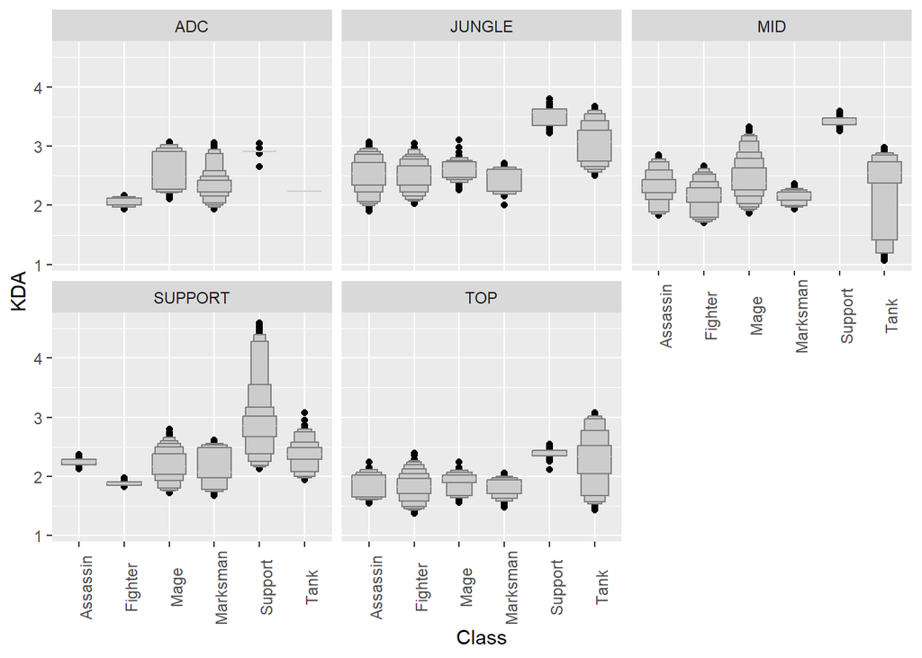

```r
#distribution of KDA by role and class
ggplot(data=leaguedf) +
  geom_lv(mapping=aes(x=Class, y=KDA)) +
  facet_wrap(~Role) +
  theme(axis.text.x =element_text(angle=90))
```

```r
classRoleAgg <- leaguedf %>%
  group_by(Class, Role) %>%
  summarize(
    `E(WinRate)` = mean(Win..),
    `Var(WinRate)`=sd(Win..),
    `E(KDA)` = mean(KDA),
    `Var(KDA)`=sd(KDA)
  ) %>%
  ungroup()
head(classRoleAgg)
```

```
## # A tibble: 6 × 6
##   Class    Role    `E(WinRate)` `Var(WinRate)` `E(KDA)` `Var(KDA)`
##   <chr>    <chr>          <dbl>          <dbl>    <dbl>      <dbl>
## 1 Assassin JUNGLE         0.494        0.0210      2.53     0.263
## 2 Assassin MID            0.498        0.0136      2.32     0.226
## 3 Assassin SUPPORT        0.493        0.0107      2.25     0.0628
## 4 Assassin TOP            0.494        0.0171      1.89     0.187
## 5 Fighter  ADC            0.503        0.00982     2.06     0.0687
## 6 Fighter  JUNGLE         0.503        0.0139      2.51     0.220
```

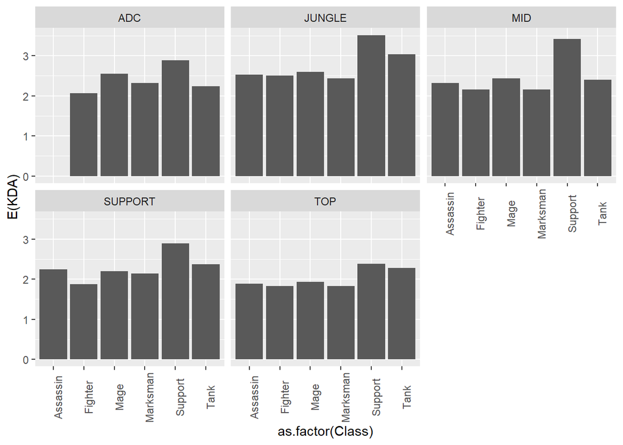

```r
#expected KDA by role and class
ggplot(data=classRoleAgg, mapping=aes(as.factor(Class), y=`E(KDA)`)) +
  geom_bar(stat="identity") +
  facet_wrap(~Role) +
  theme(axis.text.x =element_text(angle=90))
```

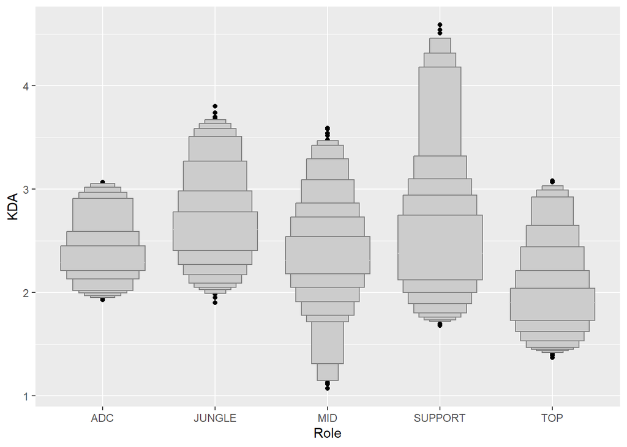

```r
  #average KDA by role and role%
roleKDA<-  ggplot(data=leaguedf) +
    geom_point(mapping=aes(x=`Role..`, y=KDA, color=Class)) +
    geom_smooth(method="lm", mapping=aes(x=`Role..`, y=KDA)) +
    facet_wrap(~Role)  +
    ggtitle("average KDA by class, role%, facet by role")

  #distributions of KDA within roles
  ggplot(data=leaguedf) +
    geom_lv(mapping=aes(x=Role, y=KDA))
```

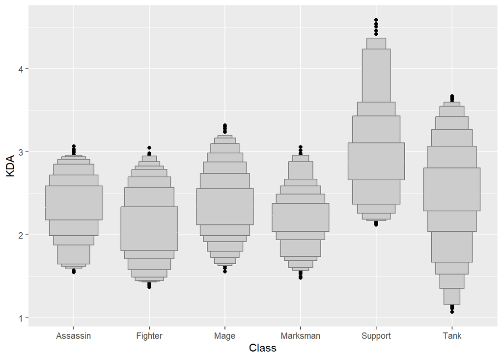

```r
#KDA by class
  classKDA <- leaguedf %>%
  group_by(Class) %>%
    summarize(
      AvgKDAByClass = mean(KDA),
      SD_KDA_Class = sd(KDA)
    )

#average KDA by class and role%
classKDA <- ggplot(data=leaguedf) +
    geom_point(mapping=aes(x=`Role..`, y=KDA, color=Role)) +
    geom_smooth(method="lm", mapping=aes(x=`Role..`, y=KDA)) +
    facet_wrap(~Class) +
    ggtitle("average KDA by role, role%, facet by class")

  #distributions of KDA within roles
  ggplot(data=leaguedf) +
    geom_lv(mapping=aes(x=Class, y=KDA))
```

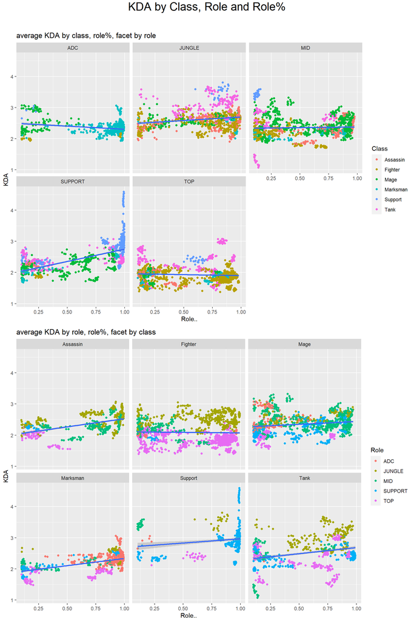

```r
grid.arrange(roleKDA, classKDA, nrow=2,
             top=textGrob("KDA by Class, Role and Role%\n",
                          gp=gpar(fontsize=20)))
```

### average KDA by role, role%, and class plot, facet by role

In the average KDA by role and role% plot, we can see that there is a very positive correlation between KDA and role percentage for support, which means that for the picks that are designed to be support tends to yield better results than the off-meta picks. Since supports acquire a lot less gold than any other roles, the picks that are designed for the lack of gold will be rewarded.

There are weak positive correlations between KDA and role% in jungle and mid. In this case, the traditional picks are still rewarded.

In the top role, there is a slightly negative correlations between KDA and role%. Top picks tend to be the frontline which would lower their KDA. Also since top is a 1v1 role in a relatively isolated environment, counterpicks are also available to lower the KDA because off-meta picks could also be a hard counter to certain picks. Top matchups tend to be more unplayable which leads to significant lower KDAs. Most of the classes in top other than the fighters have a positive trend between KDA and role%.

Just like the top role, adc also have the problem with survival in fights as they only build damage items and are the most targeted/prioritized. Whereas if one picked certain nontraditional picks, it can increase the survival rate depending on the team composition (not needing a DPS threat). For example, in the adc facet, there are a lot of green dots (mages) with higher KDAs than the traditional marksman despite the low pick rate.

We will see much clearer why some of these correlations between KDA and role% is negative when we facet by class.

### average KDA by role, role%, and class plot, facet by class

Assassin, mage, marksman, support, and tank all have positive correlations between KDA and role%. Tank, albeit also found in the top role, tend to be able to survive more pressure than fighters given their survivability. A lot of tanks also were not played in top but rather in other roles.

Fighters have a volatile nature especially in the top role because they do more damage and have much less survivability. But say one side is behind in gold, the fighter would also lose damage needed for fighting back and therefore result in a terrible KDA.

## Q2: What are the most popular champions in top lane between different servers and their performance(win rate, ban rate, pick rate) throughout the patches?

```r
patch <- unique(leaguedf$Patch)

patchFactor <- factor(patch)

AvgPickRateNA <- leaguedfNA%>%
  select(-1) %>%
  group_by(Name, Role) %>%
  summarize(
    TotalAvgPickRate=mean(`Pick..`),
    TotalAvgWinRate=mean(`Win..`),
    TotalAvgBanRate=mean(`Ban..`)
  ) %>% ungroup()
```

```r
topNA<-head(AvgPickRateNA %>%
  filter(Role=="TOP") %>%
  arrange(desc(TotalAvgPickRate)),
  5)$Name

topNA1 <- ggplot(data=(leaguedfNA[leaguedfNA$Name %in% topNA, ] %>%
         filter(Role=="TOP") %>% arrange(Name))) +
  geom_line(mapping=aes(x=factor(Patch, levels = patchFactor), y=`Win..`, color=Name,
                        group=Name)) +
  theme(axis.text.x = element_text(angle = 90, vjust = 0.5, hjust=1)) +
  ylab("Win Rate") + xlab("Patch") +
  ggtitle("NA TOP role Win Rate by Patch")

topNA2 <- ggplot(data=(leaguedfNA[leaguedfNA$Name %in% topNA, ] %>%
         filter(Role=="TOP") %>% arrange(Name))) +
  geom_line(mapping=aes(x=factor(Patch, levels = patchFactor), y=`Ban..`, color=Name,
                        group=Name)) +
  theme(axis.text.x = element_text(angle = 90, vjust = 0.5, hjust=1))+
  ylab("Ban Rate") + xlab("Patch") +
  ggtitle("NA TOP role Ban Rate by Patch")

topNA3 <- ggplot(data=(leaguedfNA[leaguedfNA$Name %in% topNA, ] %>%
         filter(Role=="TOP") %>% arrange(Name))) +
  geom_line(mapping=aes(x=factor(Patch, levels = patchFactor), y=`Pick..`, color=Name,
                        group=Name)) +
  theme(axis.text.x = element_text(angle = 90, vjust = 0.5, hjust=1))+
  ylab("Pick Rate") + xlab("Patch") +
  ggtitle("NA TOP role Pick Rate by Patch")
```

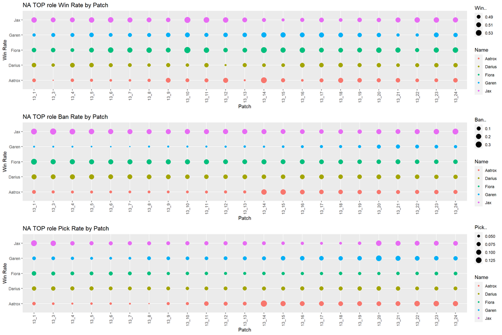

```r
topNApoint1 <- ggplot(data=(leaguedfNA[leaguedfNA$Name %in% topNA, ] %>%
         filter(Role=="TOP") %>% arrange(Name))) +
  geom_count(mapping=aes(x=factor(Patch, levels = patchFactor), y=Name, size=`Win..`,
                         color=Name)) +
  theme(axis.text.x = element_text(angle = 90, vjust = 0.5, hjust=1)) +
  ylab("Win Rate") + xlab("Patch") +
  ggtitle("NA TOP role Win Rate by Patch")

topNApoint2 <- ggplot(data=(leaguedfNA[leaguedfNA$Name %in% topNA, ] %>%
         filter(Role=="TOP") %>% arrange(Name))) +
  geom_count(mapping=aes(x=factor(Patch, levels = patchFactor), y=Name, size=`Ban..`,
                         color=Name)) +
  theme(axis.text.x = element_text(angle = 90, vjust = 0.5, hjust=1)) +
  ylab("Win Rate") + xlab("Patch") +
  ggtitle("NA TOP role Ban Rate by Patch")

topNApoint3 <- ggplot(data=(leaguedfNA[leaguedfNA$Name %in% topNA, ] %>%
         filter(Role=="TOP") %>% arrange(Name))) +
  geom_count(mapping=aes(x=factor(Patch, levels = patchFactor), y=Name, size=`Pick..`,
                         color=Name)) +
  theme(axis.text.x = element_text(angle = 90, vjust = 0.5, hjust=1)) +
  ylab("Win Rate") + xlab("Patch") +
  ggtitle("NA TOP role Pick Rate by Patch")

grid.arrange(topNApoint1, topNApoint2, topNApoint3, nrow=3)
```

In 13_14 patch in the NA server, Aatrox’s winrate skyrocked with respect to the previous patch and his ban rate and pick rate responded the same way.

In general, other than Aatrox, the ban rate and the pick rate tends to be fairly consistent. For example, Jax’s win rate fluctuates quite a bit throughout the season, yet the ban rate stayed fairly constant, same with Darius, Fiora, and Garen.

NA server has a really casual environment that the players are not quite as sensitive to meta as some other servers. This server also tends to be regarded as one of the worst servers in terms of skill.

```r
AvgPickRateKR <- leaguedfKR%>%
  select(-1) %>%
  group_by(Name, Role) %>%
  summarize(
    TotalAvgPickRate=mean(`Pick..`),
    TotalAvgWinRate=mean(`Win..`),
    TotalAvgBanRate=mean(`Ban..`)
  ) %>% ungroup()
```

```r
topKR<-head(AvgPickRateKR %>%
  filter(Role=="TOP") %>%
  arrange(desc(TotalAvgPickRate)),
  5)$Name

topKR1 <- ggplot(data=(leaguedfKR[leaguedfKR$Name %in% topKR, ] %>%
         filter(Role=="TOP") %>% arrange(Name))) +
  geom_line(mapping=aes(x=factor(Patch, levels = patchFactor), y=`Win..`, color=Name,
                        group=Name)) +
  theme(axis.text.x = element_text(angle = 90, vjust = 0.5, hjust=1)) +
  ylab("Win Rate") + xlab("Patch") +
  ggtitle("KR TOP role Win Rate by Patch")

topKR2 <- ggplot(data=(leaguedfKR[leaguedfKR$Name %in% topKR, ] %>%
         filter(Role=="TOP") %>% arrange(Name))) +
  geom_line(mapping=aes(x=factor(Patch, levels = patchFactor), y=`Ban..`, color=Name,
                        group=Name)) +
  theme(axis.text.x = element_text(angle = 90, vjust = 0.5, hjust=1))+
  ylab("Ban Rate") + xlab("Patch") +
  ggtitle("KR TOP role Ban Rate by Patch")

topKR3 <- ggplot(data=(leaguedfKR[leaguedfKR$Name %in% topKR, ] %>%
         filter(Role=="TOP") %>% arrange(Name))) +
  geom_line(mapping=aes(x=factor(Patch, levels = patchFactor), y=`Pick..`, color=Name,
                        group=Name)) +
  theme(axis.text.x = element_text(angle = 90, vjust = 0.5, hjust=1))+
  ylab("Pick Rate") + xlab("Patch") +
  ggtitle("KR TOP role Pick Rate by Patch")
```

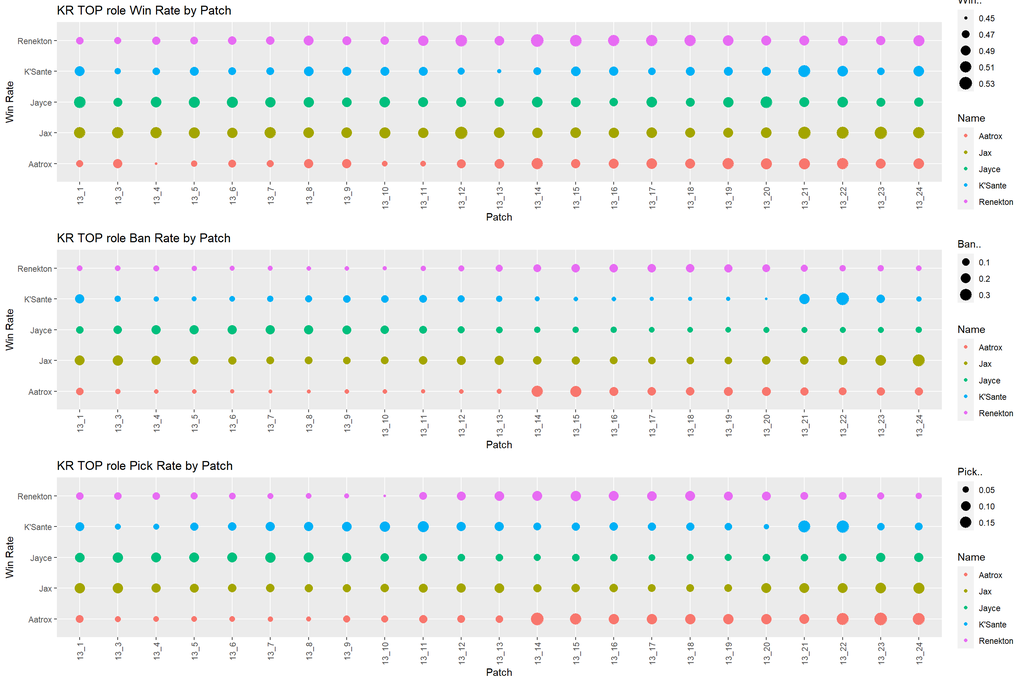

```r
topKRpoint1 <- ggplot(data=(leaguedfKR[leaguedfKR$Name %in% topKR, ] %>%
         filter(Role=="TOP") %>% arrange(Name))) +
  geom_count(mapping=aes(x=factor(Patch, levels = patchFactor), y=Name, size=`Win..`,
                         color=Name)) +
  theme(axis.text.x = element_text(angle = 90, vjust = 0.5, hjust=1)) +
  ylab("Win Rate") + xlab("Patch") +
  ggtitle("KR TOP role Win Rate by Patch")

topKRpoint2 <- ggplot(data=(leaguedfKR[leaguedfKR$Name %in% topKR, ] %>%
         filter(Role=="TOP") %>% arrange(Name))) +
  geom_count(mapping=aes(x=factor(Patch, levels = patchFactor), y=Name, size=`Ban..`,
                         color=Name)) +
  theme(axis.text.x = element_text(angle = 90, vjust = 0.5, hjust=1)) +
  ylab("Win Rate") + xlab("Patch") +
  ggtitle("KR TOP role Ban Rate by Patch")

topKRpoint3 <- ggplot(data=(leaguedfKR[leaguedfKR$Name %in% topKR, ] %>%
         filter(Role=="TOP") %>% arrange(Name))) +
  geom_count(mapping=aes(x=factor(Patch, levels = patchFactor), y=Name, size=`Pick..`,
                         color=Name)) +
  theme(axis.text.x = element_text(angle = 90, vjust = 0.5, hjust=1)) +
  ylab("Win Rate") + xlab("Patch") +
  ggtitle("KR TOP role Pick Rate by Patch")

grid.arrange(topKRpoint1, topKRpoint2, topKRpoint3, nrow=3)
```

In 13_14 patch in the KR server, Aatrox’s winrate skyrocked with respect to the previous patch and his ban rate and pick rate responded the same way.

In patch 13_21 in the KR server, K’Sante’s win rate went up by a considerable amount. In the subsequent patches, the pick rate and ban rate also skyrocked. As his win rate went down later, the pick rate and ban rate also went down.

Jax’s win rate went up at the end of the season resulting in increase in ban rate and pick rate.

Jayce’s win rate had fluctuations around 50% throughout the season, but the ban rate gradually decreases in throughout the season.

Renekton’s ban rate and pick rate corresponds really well with his win rate that as the win rate goes up, so does his ban rate and pick rate.

Korea server is the most competitive server. Their players tend to have much better mechanics at champions than other regions so they fight a lot. Because of its competitiveness, the players tend to really pay attention to meta and adjust their bans and picks.

```r
AvgPickRateEUW <- leaguedfEUW%>%
  select(-1) %>%
  group_by(Name, Role) %>%
  summarize(
    TotalAvgPickRate=mean(`Pick..`),
    TotalAvgWinRate=mean(`Win..`),
    TotalAvgBanRate=mean(`Ban..`)
  ) %>% ungroup()
```

```r
topEUW<-head(AvgPickRateEUW %>%
  filter(Role=="TOP") %>%
  arrange(desc(TotalAvgPickRate)),
  5)$Name

topEUW1 <- ggplot(data=(leaguedfEUW[leaguedfEUW$Name %in% topEUW, ] %>%
         filter(Role=="TOP") %>% arrange(Name))) +
  geom_line(mapping=aes(x=factor(Patch, levels = patchFactor), y=`Win..`, color=Name,
                        group=Name)) +
  theme(axis.text.x = element_text(angle = 90, vjust = 0.5, hjust=1)) +
  ylab("Win Rate") + xlab("Patch") +
  ggtitle("EUW TOP role Win Rate by Patch")

topEUW2 <- ggplot(data=(leaguedfEUW[leaguedfEUW$Name %in% topEUW, ] %>%
         filter(Role=="TOP") %>% arrange(Name))) +
  geom_line(mapping=aes(x=factor(Patch, levels = patchFactor), y=`Ban..`, color=Name,
                        group=Name)) +
  theme(axis.text.x = element_text(angle = 90, vjust = 0.5, hjust=1))+
  ylab("Ban Rate") + xlab("Patch") +
  ggtitle("EUW TOP role Ban Rate by Patch")

topEUW3 <- ggplot(data=(leaguedfEUW[leaguedfEUW$Name %in% topEUW, ] %>%
         filter(Role=="TOP") %>% arrange(Name))) +
  geom_line(mapping=aes(x=factor(Patch, levels = patchFactor), y=`Pick..`, color=Name,
                        group=Name)) +
  theme(axis.text.x = element_text(angle = 90, vjust = 0.5, hjust=1))+
  ylab("Pick Rate") + xlab("Patch")+
  ggtitle("KR TOP role Pick Rate by Patch")
```

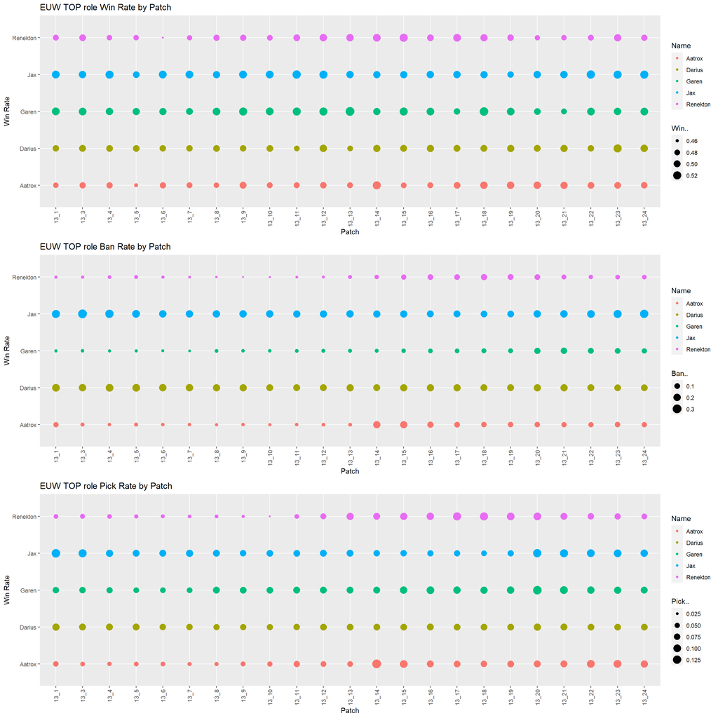

```r
topEUWpoint1 <- ggplot(data=(leaguedfEUW[leaguedfEUW$Name %in% topEUW, ] %>%
         filter(Role=="TOP") %>% arrange(Name))) +
  geom_count(mapping=aes(x=factor(Patch, levels = patchFactor), y=Name, size=`Win..`,
                         color=Name)) +
  theme(axis.text.x = element_text(angle = 90, vjust = 0.5, hjust=1)) +
  ylab("Win Rate") + xlab("Patch") +
  ggtitle("EUW TOP role Win Rate by Patch")

topEUWpoint2 <- ggplot(data=(leaguedfEUW[leaguedfEUW$Name %in% topEUW, ] %>%
         filter(Role=="TOP") %>% arrange(Name))) +
  geom_count(mapping=aes(x=factor(Patch, levels = patchFactor), y=Name, size=`Ban..`,
                         color=Name)) +
  theme(axis.text.x = element_text(angle = 90, vjust = 0.5, hjust=1)) +
  ylab("Win Rate") + xlab("Patch") +
  ggtitle("EUW TOP role Ban Rate by Patch")

topEUWpoint3 <- ggplot(data=(leaguedfEUW[leaguedfEUW$Name %in% topEUW, ] %>%
         filter(Role=="TOP") %>% arrange(Name))) +
  geom_count(mapping=aes(x=factor(Patch, levels = patchFactor), y=Name, size=`Pick..`,
                         color=Name)) +
  theme(axis.text.x = element_text(angle = 90, vjust = 0.5, hjust=1)) +
  ylab("Win Rate") + xlab("Patch") +
  ggtitle("EUW TOP role Pick Rate by Patch")

grid.arrange(topEUWpoint1, topEUWpoint2, topEUWpoint3, nrow=3)
```

In 13_14 patch in the EUW server, Aatrox’s winrate skyrocked with respect to the previous patch and his ban rate and pick rate responded the same way.

Darius’ win rate fluctuated throughout the season, but the ban rate and pick rate did not necessarily respond to these fluctuations.

Garen’s win rate fluctuated throughout the season, but his ban rate and pick rate went up throughout the season.

Jax’s win rate was high (fluctuating between 50% to 52%) and this ban rate and pick rate was consistently high.

Renekton’s win rate went up throughout the season and so is his pick rate and ban rate.

EUW is a big server with a big population. They tend to have a more proactive playstyle that they would try to make plays instead of waiting for things to happen. This server tends to be better at making macro decisions (taking objectives on the map).

#### Summary of the 3 servers

[figure not shown]

```r
#the graph to include for EDA
grid.arrange(topNA1, topNA2, topNA3,
             topKR1, topKR2, topKR3,
             topEUW1, topEUW2, topEUW3,
             nrow=9,
             top=textGrob("5 Most Popular Champions for the TOP role in 3 servers\n",
                          gp=gpar(fontsize=20)))
```

Other than K’sante (tank), all these picks are fighters. All these picks are good at early to mid game skirmishes and exerting pressure on the map. And K’sante’s ultimate ability turns him into a fighter temporarily. Because they are fighters, they have much more carry potential because of the amount of damage they can dish out.

# Follow up Question:

## How does the relationship of using role %, role and class to predict KDA differ by regions (NA, EUW, KR)?

### North America

```r
predKDA_NA<- lm(KDA~Class + Role + `Role..`, data= leaguedfNA)
summary(predKDA_NA)
```

```
##
## Call:
## lm(formula = KDA ~ Class + Role + Role.., data = leaguedfNA)
##
## Residuals:
##      Min       1Q   Median       3Q      Max
## -1.38394 -0.16412 -0.01816  0.14285  1.67057
##
## Coefficients:
##               Estimate Std. Error t value Pr(>|t|)
## (Intercept)    2.27173    0.01991 114.114  < 2e-16 ***
## ClassFighter  -0.09887    0.01330  -7.433 1.22e-13 ***
## ClassMage      0.11800    0.01380   8.549  < 2e-16 ***
## ClassMarksman -0.08420    0.01675  -5.026 5.17e-07 ***
## ClassSupport   0.73114    0.01933  37.822  < 2e-16 ***
## ClassTank      0.29591    0.01528  19.363  < 2e-16 ***
## RoleJUNGLE     0.21204    0.01608  13.184  < 2e-16 ***
## RoleMID       -0.06348    0.01519  -4.179 2.97e-05 ***
## RoleSUPPORT   -0.20397    0.01670 -12.212  < 2e-16 ***
## RoleTOP       -0.46347    0.01564 -29.628  < 2e-16 ***
## Role..         0.15154    0.01183  12.811  < 2e-16 ***
## ---
## Signif. codes:  0 '***' 0.001 '**' 0.01 '*' 0.05 '.' 0.1 ' ' 1
##
## Residual standard error: 0.2732 on 5778 degrees of freedom
## Multiple R-squared:  0.5919, Adjusted R-squared:  0.5912
## F-statistic: 838.1 on 10 and 5778 DF,  p-value: < 2.2e-16
```

```r
anova(predKDA_NA)
```

```
## Analysis of Variance Table
##
## Response: KDA
##             Df Sum Sq Mean Sq F value    Pr(>F)
## Class        5 300.91  60.182  806.50 < 2.2e-16 ***
## Role         4 312.24  78.059 1046.08 < 2.2e-16 ***
## Role..       1  12.25  12.247  164.12 < 2.2e-16 ***
## Residuals 5778 431.16   0.075
## ---
## Signif. codes:  0 '***' 0.001 '**' 0.01 '*' 0.05 '.' 0.1 ' ' 1
```

With Role, Role%, and class as predictors, we can explain up to 59.2% of the variability in KDA which makes sense as the rest of the variability could be attributed to the difference in skill/performance of players and other factors. All of the predictors are significant at a 5% level for predicting KDA in the North America server.

In the summary, each of the categories such as roles and class changes the intercept of the linear regression to predict the KDA. For example, if we are looking at a TOP role and a Fighter class, we would subtract 0.09887 and 0.46347 from the intercept. In the ANOVA test, we see that every additional predictor is significant in explaining more of the variation in the data compared to the previous subset of predictors (since the test is nested).

In the context of the data, it means that playing champions of a class in their conventional roles or not can to some extent predict the performance of the champion in a game in the North America server. Because the role has a positive slope (0.15154) with respect to KDA, it means that playing conventional picks in terms of class and role tend to yield better results and performance in a game.

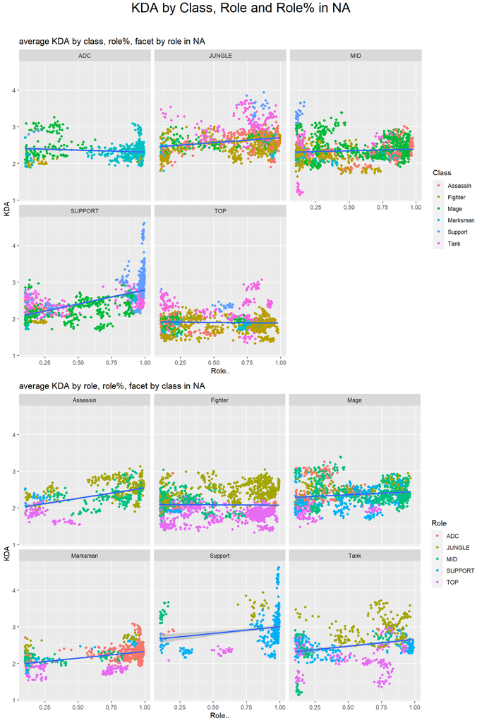

```r
#average KDA by role and role% in NA
roleKDA_NA<-  ggplot(data=leaguedfNA) +
    geom_point(mapping=aes(x=`Role..`, y=KDA, color=Class)) +
    geom_smooth(method="lm", mapping=aes(x=`Role..`, y=KDA)) +
    facet_wrap(~Role)  +
    ggtitle("average KDA by class, role%, facet by role in NA")

#average KDA by class and role in NA%
classKDA_NA <- ggplot(data=leaguedfNA) +
    geom_point(mapping=aes(x=`Role..`, y=KDA, color=Role)) +
    geom_smooth(method="lm", mapping=aes(x=`Role..`, y=KDA)) +
    facet_wrap(~Class) +
    ggtitle("average KDA by role, role%, facet by class in NA")

grid.arrange(roleKDA_NA, classKDA_NA, nrow=2,
             top=textGrob("KDA by Class, Role and Role% in NA\n",
                          gp=gpar(fontsize=20)))
```

In general, the TOP and the ADC have the lower KDA the higher the role%. Within the ADC specifically, it is because the mages have a low role% which lift the left of the graph up so that the standard marksman ADC actually seemed to have lower KDAs. But in the facet by class graph, the marksman KDA actually increases as the as the role% increases with the ADC role as the mainstream marksmen players.

While for the fighters, in the first graph (facet by role), they make up the data with the lowest KDAs in the TOP role. In the second graph (facet by class), the fighters that played in the TOP role have the lowest KDAs. While other roles such as MID (short lane, less kill potential), ADC(2 players), and JUNGLE (PVE gameplay, fighting jungle) are less of that nature.

The mages in the ADC role had some relative success compared to ADC according to the first graph, but there are not a lot mages in the ADC role which means that it is good conditionally as a pick for ADC. Amongst the mages, the ones who played ADC had relative success according to the second graph compared to the standard MID mages, but only picked conditionally.

The marksman picked in the TOP role tend to have lower KDAs as they are susceptible to JUNGLE interference. And also in teamfights, it is likely that the team with a marksman TOP does not have a frontline.

The assassins in the JUNGLE role saw relatively more success than assassins in the MID role as given their nature of burst damage and mobility, they would have more success catching people in lanes off guard.

Tanks have lower KDAs in TOP even with more role%. Tanks are useless in MID lane shown by their low KDAs because they don’t have enough kill pressure in a short lane (MID) nor do they have good roam potential, while the tanks in the JUNGLE role performs quite well for their crown control capabilities.

Supports have the highest KDAs and the conventional picks are successful. Supports also found some success in MID and JUNGLE but very conditionally because there is not a lot of data points for support in MID and JUNGLE. Supports suffered in TOP.

### Korea

```r
predKDA_KR<- lm(KDA~Class + Role + `Role..`, data= leaguedfKR)
summary(predKDA_KR)
```

```
##
## Call:
## lm(formula = KDA ~ Class + Role + Role.., data = leaguedfKR)
##
## Residuals:
##      Min       1Q   Median       3Q      Max
## -1.83290 -0.17731 -0.02108  0.15436  2.06455
##
## Coefficients:
##               Estimate Std. Error t value Pr(>|t|)
## (Intercept)    2.42731    0.02049 118.466   <2e-16 ***
## ClassFighter  -0.11399    0.01345  -8.474   <2e-16 ***
## ClassMage      0.09316    0.01386   6.720    2e-11 ***
## ClassMarksman -0.16024    0.01668  -9.608   <2e-16 ***
## ClassSupport   0.71339    0.01920  37.160   <2e-16 ***
## ClassTank      0.37179    0.01522  24.427   <2e-16 ***
## RoleJUNGLE     0.13634    0.01646   8.285   <2e-16 ***
## RoleMID       -0.18851    0.01602 -11.769   <2e-16 ***
## RoleSUPPORT   -0.42906    0.01668 -25.729   <2e-16 ***
## RoleTOP       -0.60231    0.01595 -37.757   <2e-16 ***
## Role..         0.13410    0.01191  11.258   <2e-16 ***
## ---
## Signif. codes:  0 '***' 0.001 '**' 0.01 '*' 0.05 '.' 0.1 ' ' 1
##
## Residual standard error: 0.278 on 5882 degrees of freedom
## Multiple R-squared:  0.6124, Adjusted R-squared:  0.6117
## F-statistic: 929.4 on 10 and 5882 DF,  p-value: < 2.2e-16
```

```r
anova(predKDA_KR)
```

```
## Analysis of Variance Table
##
## Response: KDA
##             Df Sum Sq Mean Sq F value    Pr(>F)
## Class        5 294.42  58.885  762.01 < 2.2e-16 ***
## Role         4 413.96 103.489 1339.22 < 2.2e-16 ***
## Role..       1   9.79   9.795  126.75 < 2.2e-16 ***
## Residuals 5882 454.54   0.077
## ---
## Signif. codes:  0 '***' 0.001 '**' 0.01 '*' 0.05 '.' 0.1 ' ' 1
```

With Role, Role%, and class as predictors, we can explain up to 61.2% of the variability in KDA which makes sense as the rest of the variability could be attributed to the difference in skill/performance of players and other factors. All of the predictors are significant at a 5% level for predicting KDA in the Korea server.

In the summary, each of the categories such as roles and class changes the intercept of the linear regression to predict the KDA. For example, if we are looking at a TOP role and a Fighter class, we would subtract 0.11399 and 0.60231 from the intercept. In the ANOVA test, we see that every additional predictor is significant in explaining more of the variation in the data compared to the previous subset of predictors (since the test is nested).

In the context of the data, it means that playing champions of a class in their conventional roles or not can to some extent predict the performance of the champion in a game in the Korea server. Because the role has a positive slope (0.13410) with respect to KDA, it means that playing conventional picks in terms of class and role tend to yield better results and performance in a game.

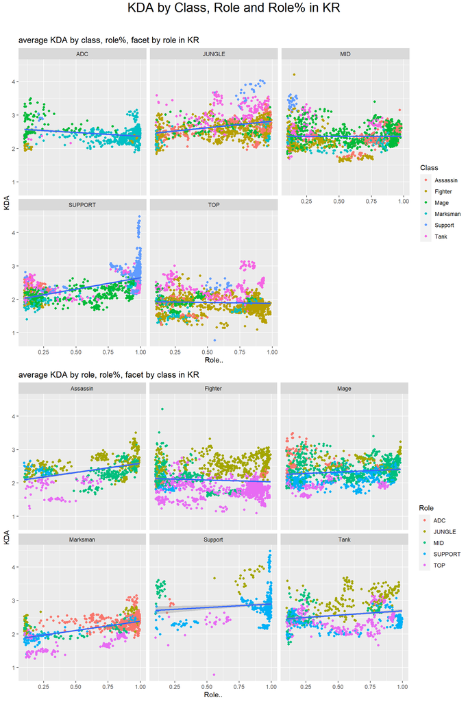

```r
#average KDA by role and role% in KR
roleKDA_KR<-  ggplot(data=leaguedfKR) +
    geom_point(mapping=aes(x=`Role..`, y=KDA, color=Class)) +
    geom_smooth(method="lm", mapping=aes(x=`Role..`, y=KDA)) +
    facet_wrap(~Role)  +
    ggtitle("average KDA by class, role%, facet by role in KR")

#average KDA by class and role in KR%
classKDA_KR <- ggplot(data=leaguedfKR) +
    geom_point(mapping=aes(x=`Role..`, y=KDA, color=Role)) +
    geom_smooth(method="lm", mapping=aes(x=`Role..`, y=KDA)) +
    facet_wrap(~Class) +
    ggtitle("average KDA by role, role%, facet by class in KR")

grid.arrange(roleKDA_KR, classKDA_KR, nrow=2,
             top=textGrob("KDA by Class, Role and Role% in KR\n",
                          gp=gpar(fontsize=20)))
```

Similar trends in the North America server is found in the Korea server that fighters in TOP tend to have the lowest KDAs while the fighters in JUNGLE do much better. Mage ADC are quite viable at times. Mages are successful in JUNGLE and MID. Tanks being useless in the MID role and good in JUNGLE. Marksman in top also have relatively lower KDAs but are consistently good in the ADC role. Assassins are good in JUNGLE and MID. Supports are good in SUPPORT consistently, good in MID and JUNGLE conditionally, and unoptimal in TOP.

### Europe West

```r
predKDA_EUW<- lm(KDA~Class + Role + `Role..`, data= leaguedfEUW)
summary(predKDA_EUW)
```

```
##
## Call:
## lm(formula = KDA ~ Class + Role + Role.., data = leaguedfEUW)
##
## Residuals:
##      Min       1Q   Median       3Q      Max
## -1.45764 -0.16690 -0.01714  0.14521  2.05268
##
## Coefficients:
##               Estimate Std. Error t value Pr(>|t|)
## (Intercept)    2.23213    0.02007 111.211  < 2e-16 ***
## ClassFighter  -0.08459    0.01344  -6.293 3.36e-10 ***
## ClassMage      0.10923    0.01381   7.911 3.05e-15 ***
## ClassMarksman -0.07512    0.01700  -4.417 1.02e-05 ***
## ClassSupport   0.78250    0.01930  40.549  < 2e-16 ***
## ClassTank      0.34995    0.01538  22.753  < 2e-16 ***
## RoleJUNGLE     0.26814    0.01626  16.493  < 2e-16 ***
## RoleMID       -0.02662    0.01534  -1.736   0.0827 .
## RoleSUPPORT   -0.19017    0.01691 -11.247  < 2e-16 ***
## RoleTOP       -0.45705    0.01563 -29.234  < 2e-16 ***
## Role..         0.13979    0.01205  11.598  < 2e-16 ***
## ---
## Signif. codes:  0 '***' 0.001 '**' 0.01 '*' 0.05 '.' 0.1 ' ' 1
##
## Residual standard error: 0.2688 on 5539 degrees of freedom
## Multiple R-squared:  0.6302, Adjusted R-squared:  0.6295
## F-statistic:   944 on 10 and 5539 DF,  p-value: < 2.2e-16
```

```r
anova(predKDA_EUW)
```

```
## Analysis of Variance Table
##
## Response: KDA
##             Df Sum Sq Mean Sq F value    Pr(>F)
## Class        5 333.43  66.687  922.94 < 2.2e-16 ***
## Role         4 338.91  84.727 1172.61 < 2.2e-16 ***
## Role..       1   9.72   9.719  134.51 < 2.2e-16 ***
## Residuals 5539 400.22   0.072
## ---
## Signif. codes:  0 '***' 0.001 '**' 0.01 '*' 0.05 '.' 0.1 ' ' 1
```

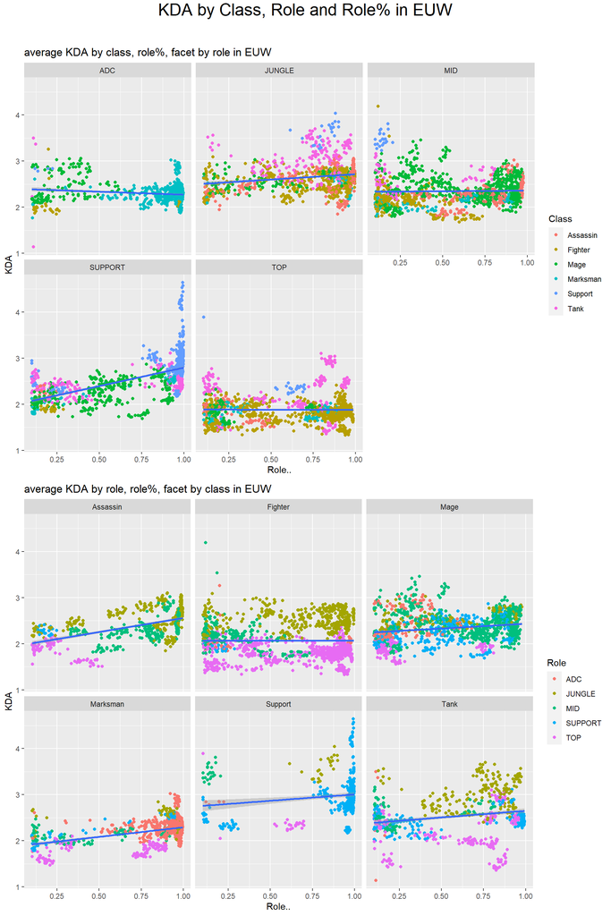

```r
#average KDA by role and role% in EUW
roleKDA_EUW<-  ggplot(data=leaguedfEUW) +
    geom_point(mapping=aes(x=`Role..`, y=KDA, color=Class)) +
    geom_smooth(method="lm", mapping=aes(x=`Role..`, y=KDA)) +
    facet_wrap(~Role)  +
    ggtitle("average KDA by class, role%, facet by role in EUW")

#average KDA by class and role in EUW%
classKDA_EUW <- ggplot(data=leaguedfEUW) +
    geom_point(mapping=aes(x=`Role..`, y=KDA, color=Role)) +
    geom_smooth(method="lm", mapping=aes(x=`Role..`, y=KDA)) +
    facet_wrap(~Class) +
    ggtitle("average KDA by role, role%, facet by class in EUW")

grid.arrange(roleKDA_EUW, classKDA_EUW, nrow=2,
             top=textGrob("KDA by Class, Role and Role% in EUW\n",
                          gp=gpar(fontsize=20)))
```

Similar trends in the North America server and the Korea server is found in the Europe West server that fighters in TOP tend to have the lowest KDAs while the fighters in JUNGLE do much better. Mage ADC are quite viable at times. Mages are successful in JUNGLE and MID. Tanks being useless in the MID role and good in JUNGLE. Marksman in top also have relatively lower KDAs but are consistently good in the ADC role. Assassins are good in JUNGLE and MID. Supports are good in SUPPORT consistently, good in MID and JUNGLE conditionally, and unoptimal in TOP.

### Summary

#### Results from the ANOVA and summary of linear models

North American server rewarded conventional picks in terms of role and class a slightly more because of a bigger slope than both EUW and KR server. In all 3 servers, picking fighters and marksmen tend yield lower KDAs while the other class are likely to have higher KDAs because of the negative intercept added when fighters and marksmen are selected for the model.

EUW is a proactive region on macro-plays (taking objectives on the map). Their jungle has the biggest positive intercept change (0.26814) of the 3 regions which means that if the champion is played in the jungle, it is statistically more likely to have higher KDAs than other regions.

#### Results from the ggplots

[figure not shown]

```r
grid.arrange(roleKDA_NA, roleKDA_KR, roleKDA_EUW,
             classKDA_NA, classKDA_KR, classKDA_EUW,
             nrow=6,
             top=textGrob("KDA by Class, Role and Role% in the 3 Servers\n",
                          gp=gpar(fontsize=20)))
```

In the MID role in EUW, there is no correlation between role% and KDA. Among MID in EUW, assassins have a positive correlation. Mages have an neutral association. Supports are really high up in the left tail (high leverage) which decreases the overall correlation between KDA and role% by quite a bit. Marksman have a little correlation between KDA and role% and so do tanks. In the MID role, NA has a positive trend that as role% increases, the KDA also increases. Among MID in NA, tanks do really bad (low KDA) with a low role% (high leverage), which contributes greatly to overall positive in NA. Mages, fighters, supports, marksman, and assassins all had similar individual correlations between KDA and role%. In KR, the correlation between KDA and role% are also about neutral. Mages, fighters, supports, marksman, and assassins all had similar individual correlations between KDA and role% in Korea. Therefore, we can conclude that the main issue with the positive correlation in NA is the nontraditional tank picks in the MID role performing badly.

Of the 6 classes in the 3 regions, other than the fighter class that has a negative correlation between KDA and role%, the mage, tank, assassin, support, and marksman all have positive correlations between KDA and role%. So, the correlation of KDA and role% between the 3 regions are consistent throughout. However, there are some differences with the distribution within the classes themselves among 3 regions.

One general trend is that any class that went to the TOP lane tend to have lower KDAs than when they were played in other roles which confirms that TOP lane is an unforgiving role.

Within the tank class, in NA and EUW servers, the a cluster of tanks that went to the TOP role have a KDA around 1.5 when the role% is high. But in KR, the majority of the tanks that went the TOP lane had a KDA around 2. This concurs with the general consensus that KR has the best mechanical players. Despite fighters in general being able to pick off tanks in TOP (1v1, skill intensive role), the Korean tank players perform much better mechanically than the tank players in other regions.

Within the assassin class, a higher percentage of assassins were played TOP in KR than the other 2 regions shown by the higher role% of TOP assassins.

Within the fighter class, all three regions share similar distributions of data points in the graphs faceted by class with an overall negative trend between KDA and role%.

Within the mage class, all three regions share similar distributions of data points in the graphs faceted by class.

Within the support class, all three regions share similar distributions of data points in the graphs faceted by class.

Within the marksman class, NA, EUW, and KR have similar distributions for marksman champions going into TOP, JUNGLE, SUPPORT, and MID. However, for the ADC role, NA and EUW both had high role% for most of the marksman while KR had a lot of lower role% for quite a few marksman champions while their KDAs are consistent with the high role% markman’s KDAs. This means that KR marksman players can exploit off-meta/nontraditional picks and use them to their advantage.